# Kaggle - Healthcare Dataset-Updated

## **Healthcare Dataset - Kaggle**

### **About Dataset**

You can read more about the dataset [here](https://www.kaggle.com/datasets/prasad22/healthcare-dataset)

#### **Dataset Information:**

Each column provides specific information about the patient, their admission, and the healthcare services provided, making this dataset suitable for various data analysis and modeling tasks in the healthcare domain. Here's a brief explanation of each column in the dataset -

- **Name**: This column represents the name of the patient associated with the healthcare record.
- **Age**: The age of the patient at the time of admission, expressed in years.
- **Gender**: Indicates the gender of the patient, either "Male" or "Female."
- **Blood Type**: The patient's blood type, which can be one of the common blood types (e.g., "A+", "O-", etc.).
- **Medical Condition**: This column specifies the primary medical condition or diagnosis associated with the patient, such as "Diabetes," "Hypertension," "Asthma," and more.
- **Date of Admission**: The date on which the patient was admitted to the healthcare facility.
- **Doctor**: The name of the doctor responsible for the patient's care during their admission.
- **Hospital**: Identifies the healthcare facility or hospital where the patient was admitted.
- **Insurance Provider**: This column indicates the patient's insurance provider, which can be one of several options, including "Aetna," "Blue Cross," "Cigna," "UnitedHealthcare," and "Medicare."
- **Billing Amount**: The amount of money billed for the patient's healthcare services during their admission. This is expressed as a floating-point number.
- **Room Number**: The room number where the patient was accommodated during their admission.
- **Admission Type**: Specifies the type of admission, which can be "Emergency," "Elective," or "Urgent," reflecting the circumstances of the admission.
- **Discharge Date**: The date on which the patient was discharged from the healthcare facility, based on the admission date and a random number of days within a realistic range.
- **Medication**: Identifies a medication prescribed or administered to the patient during their admission. Examples include "Aspirin," "Ibuprofen," "Penicillin," "Paracetamol," and "Lipitor."
- **Test Results**: Describes the results of a medical test conducted during the patient's admission. Possible values include "Normal," "Abnormal," or "Inconclusive," indicating the outcome of the test.

#### **1. Importing the Libraries**

```python
import pandas as pd
                  import numpy as np
                  import seaborn as sns
                  import matplotlib.pyplot as plt
```

#### **2. Importing / Loading Data**

```python
health_data_org = pd.read_csv('data/healthcare_dataset.csv')
```

```python
health_data_org.shape
```

```
(55500, 15)
```

```python
health_data_org.select_dtypes(include = np.number).describe()
```

|  | Age | Billing Amount | Room Number |
| --- | --- | --- | --- |
| count | 55500.000000 | 55500.000000 | 55500.000000 |
| mean | 51.539459 | 25539.316097 | 301.134829 |
| std | 19.602454 | 14211.454431 | 115.243069 |
| min | 13.000000 | -2008.492140 | 101.000000 |
| 25% | 35.000000 | 13241.224652 | 202.000000 |
| 50% | 52.000000 | 25538.069376 | 302.000000 |
| 75% | 68.000000 | 37820.508436 | 401.000000 |
| max | 89.000000 | 52764.276736 | 500.000000 |

```python
health_data_org.select_dtypes(include = ['category', 'object']).describe()
```

|  | Name | Gender | Blood Type | Medical Condition | Date of Admission | Doctor | Hospital | Insurance Provider | Admission Type | Discharge Date | Medication | Test Results |
| --- | --- | --- | --- | --- | --- | --- | --- | --- | --- | --- | --- | --- |
| count | 55500 | 55500 | 55500 | 55500 | 55500 | 55500 | 55500 | 55500 | 55500 | 55500 | 55500 | 55500 |
| unique | 49992 | 2 | 8 | 6 | 1827 | 40341 | 39876 | 5 | 3 | 1856 | 5 | 3 |
| top | DAvId muNoZ | Male | A- | Arthritis | 2024-03-16 | Michael Smith | LLC Smith | Cigna | Elective | 2020-03-15 | Lipitor | Abnormal |
| freq | 3 | 27774 | 6969 | 9308 | 50 | 27 | 44 | 11249 | 18655 | 53 | 11140 | 18627 |

```python
# Convert room to categorical data.
                # new_health_data['new_room_number'] = new_health_data['Hospital'].apply(lambda x: str(x)) + " Room " + new_health_data['Room Number'].apply(lambda x: str(x))
                health_data = health_data_org.copy()
                health_data['new_room_number'] = "Room " + health_data['Room Number'].apply(lambda x: str(x))
                health_data.head()
```

|  | Name | Age | Gender | Blood Type | Medical Condition | Date of Admission | Doctor | Hospital | Insurance Provider | Billing Amount | Room Number | Admission Type | Discharge Date | Medication | Test Results | new_room_number |
| --- | --- | --- | --- | --- | --- | --- | --- | --- | --- | --- | --- | --- | --- | --- | --- | --- |
| 0 | Bobby JacksOn | 30 | Male | B- | Cancer | 2024-01-31 | Matthew Smith | Sons and Miller | Blue Cross | 18856.281306 | 328 | Urgent | 2024-02-02 | Paracetamol | Normal | Room 328 |
| 1 | LesLie TErRy | 62 | Male | A+ | Obesity | 2019-08-20 | Samantha Davies | Kim Inc | Medicare | 33643.327287 | 265 | Emergency | 2019-08-26 | Ibuprofen | Inconclusive | Room 265 |
| 2 | DaNnY sMitH | 76 | Female | A- | Obesity | 2022-09-22 | Tiffany Mitchell | Cook PLC | Aetna | 27955.096079 | 205 | Emergency | 2022-10-07 | Aspirin | Normal | Room 205 |
| 3 | andrEw waTtS | 28 | Female | O+ | Diabetes | 2020-11-18 | Kevin Wells | Hernandez Rogers and Vang, | Medicare | 37909.782410 | 450 | Elective | 2020-12-18 | Ibuprofen | Abnormal | Room 450 |
| 4 | adrIENNE bEll | 43 | Female | AB+ | Cancer | 2022-09-19 | Kathleen Hanna | White-White | Aetna | 14238.317814 | 458 | Urgent | 2022-10-09 | Penicillin | Abnormal | Room 458 |

```python
# define a function to transform dates
                import re
                def transform_date(data_set, col):
                data_set[col] = pd.to_datetime(data_set[col], format = "%Y-%m-%d")
                col_pref = re.sub(r'\b(Date of|Date)\b', '', col, flags=re.IGNORECASE).strip()
                # data_set[col_pref.lower()+"_year"] = data_set[col].dt.year
                # data_set[col_pref.lower()+"_month"] = data_set[col].dt.month
                # data_set[col_pref.lower()+"_day"] = data_set[col].dt.day
                return data_set

                # Apply the funtion to data
                transform_date(health_data, 'Date of Admission')
                transform_date(health_data, 'Discharge Date')

                # Obtain the number of days in hospital
                # (pd.to_datetime("2019-08-26", format = "%Y-%m-%d") - pd.to_datetime("2019-08-20", format = "%Y-%m-%d")).days
                health_data["Number of Days"] = (health_data['Discharge Date'] - health_data['Date of Admission']).apply(lambda x: x.days)
```

```python
# Clean data column names
                health_data.columns = [col.lower().replace(' ', '_').replace('date_of_', '').replace('date', '').strip('_') for col in health_data.columns]
                target_names = health_data.test_results.unique().tolist()
```

```python
# For each categorical columns, there are how many levels?
                cat_cols = health_data.select_dtypes(include = ['category', 'object']).columns.tolist()
                levels_dict = {}
                for cat_col in cat_cols:
                levels_dict[cat_col] = health_data[cat_col].unique().tolist()
                len(levels_dict['new_room_number'])
```

```
400
```

**Checking the correlation between categorical features and test results**

```python
from scipy.stats import chi2_contingency
```

```python
# Function to check the association of categorical variables
              def chi2_test(cat_1, cat_2, data):
              table = pd.crosstab(data[cat_1], data[cat_2])
              chi2_stat, p, dof, expected = chi2_contingency(table)
              print(f"{cat_1.title()} vs {cat_2.title()} → Chi2: {chi2_stat:.4f}, p-value: {p:.4f}, DOF: {dof}")
              return table
              chi2_test('gender', 'test_results', health_data)
```

```
Gender vs Test_Results → Chi2: 2.0184, p-value: 0.3645, DOF: 2
```

| test_results gender | Abnormal | Inconclusive | Normal |
| --- | --- | --- | --- |
| Female | 9338 | 9216 | 9172 |
| Male | 9289 | 9140 | 9345 |

```python
chi2_test('blood_type', 'test_results', health_data)
```

```
Blood_Type vs Test_Results → Chi2: 7.6317, p-value: 0.9076, DOF: 14
```

| test_results blood_type | Abnormal | Inconclusive | Normal |
| --- | --- | --- | --- |
| A+ | 2333 | 2330 | 2293 |
| A- | 2336 | 2298 | 2335 |
| AB+ | 2308 | 2325 | 2314 |
| AB- | 2333 | 2250 | 2362 |
| B+ | 2303 | 2366 | 2276 |
| B- | 2348 | 2268 | 2328 |
| O+ | 2347 | 2262 | 2308 |
| O- | 2319 | 2257 | 2301 |

```python
chi2_test('medical_condition', 'test_results', health_data)
```

```
Medical_Condition vs Test_Results → Chi2: 13.2551, p-value: 0.2098, DOF: 10
```

| test_results medical_condition | Abnormal | Inconclusive | Normal |
| --- | --- | --- | --- |
| Arthritis | 3188 | 3088 | 3032 |
| Asthma | 3009 | 3029 | 3147 |
| Cancer | 3118 | 3060 | 3049 |
| Diabetes | 3168 | 3046 | 3090 |
| Hypertension | 3012 | 3091 | 3142 |
| Obesity | 3132 | 3042 | 3057 |

```python
chi2_test('insurance_provider', 'test_results', health_data)
```

```
Insurance_Provider vs Test_Results → Chi2: 8.3776, p-value: 0.3975, DOF: 8
```

| test_results insurance_provider | Abnormal | Inconclusive | Normal |
| --- | --- | --- | --- |
| Aetna | 3631 | 3660 | 3622 |
| Blue Cross | 3638 | 3732 | 3689 |
| Cigna | 3807 | 3718 | 3724 |
| Medicare | 3784 | 3652 | 3718 |
| UnitedHealthcare | 3767 | 3594 | 3764 |

```python
chi2_test('admission_type', 'test_results', health_data)
```

```
Admission_Type vs Test_Results → Chi2: 1.3198, p-value: 0.8580, DOF: 4
```

| test_results admission_type | Abnormal | Inconclusive | Normal |
| --- | --- | --- | --- |
| Elective | 6296 | 6118 | 6241 |
| Emergency | 6091 | 6072 | 6106 |
| Urgent | 6240 | 6166 | 6170 |

```python
chi2_test('medication', 'test_results', health_data)
```

```
Medication vs Test_Results → Chi2: 3.7311, p-value: 0.8805, DOF: 8
```

| test_results medication | Abnormal | Inconclusive | Normal |
| --- | --- | --- | --- |
| Aspirin | 3732 | 3624 | 3738 |
| Ibuprofen | 3747 | 3645 | 3735 |
| Lipitor | 3707 | 3746 | 3687 |
| Paracetamol | 3737 | 3681 | 3653 |
| Penicillin | 3704 | 3660 | 3704 |

```python
chi2_test('new_room_number', 'test_results', health_data)
```

```
New_Room_Number vs Test_Results → Chi2: 948.5164, p-value: 0.0002, DOF: 798
```

| test_results new_room_number | Abnormal | Inconclusive | Normal |
| --- | --- | --- | --- |
| Room 101 | 45 | 42 | 35 |
| Room 102 | 57 | 48 | 54 |
| Room 103 | 47 | 45 | 45 |
| Room 104 | 52 | 53 | 70 |
| Room 105 | 39 | 31 | 48 |
| ... | ... | ... | ... |
| Room 496 | 53 | 60 | 55 |
| Room 497 | 52 | 51 | 41 |
| Room 498 | 49 | 46 | 44 |
| Room 499 | 33 | 38 | 55 |
| Room 500 | 42 | 38 | 47 |

400 rows × 3 columns

```python
health_data.head()
```

|  | name | age | gender | blood_type | medical_condition | admission | doctor | hospital | insurance_provider | billing_amount | room_number | admission_type | discharge | medication | test_results | new_room_number | number_of_days |
| --- | --- | --- | --- | --- | --- | --- | --- | --- | --- | --- | --- | --- | --- | --- | --- | --- | --- |
| 0 | Bobby JacksOn | 30 | Male | B- | Cancer | 2024-01-31 | Matthew Smith | Sons and Miller | Blue Cross | 18856.281306 | 328 | Urgent | 2024-02-02 | Paracetamol | Normal | Room 328 | 2 |
| 1 | LesLie TErRy | 62 | Male | A+ | Obesity | 2019-08-20 | Samantha Davies | Kim Inc | Medicare | 33643.327287 | 265 | Emergency | 2019-08-26 | Ibuprofen | Inconclusive | Room 265 | 6 |
| 2 | DaNnY sMitH | 76 | Female | A- | Obesity | 2022-09-22 | Tiffany Mitchell | Cook PLC | Aetna | 27955.096079 | 205 | Emergency | 2022-10-07 | Aspirin | Normal | Room 205 | 15 |
| 3 | andrEw waTtS | 28 | Female | O+ | Diabetes | 2020-11-18 | Kevin Wells | Hernandez Rogers and Vang, | Medicare | 37909.782410 | 450 | Elective | 2020-12-18 | Ibuprofen | Abnormal | Room 450 | 30 |
| 4 | adrIENNE bEll | 43 | Female | AB+ | Cancer | 2022-09-19 | Kathleen Hanna | White-White | Aetna | 14238.317814 | 458 | Urgent | 2022-10-09 | Penicillin | Abnormal | Room 458 | 20 |

**Checking the relationship between numeric data and test results**

**Oneway Anova using `scipy`**

```python
from scipy.stats import f_oneway

            # Group by each category
            grouped_data = [health_data[health_data['test_results'] == group]['billing_amount'] for group in health_data['test_results'].unique()]

            # Apply ANOVA
            f_stat, p_val = f_oneway(*grouped_data)

            print(f"F-statistic: {f_stat:.4f}")
            print(f"p-value: {p_val:.4f}")
```

```
F-statistic: 0.6368
            p-value: 0.5290
```

**Using statsmodels for Detailed Output**

```python
import statsmodels.api as sm
            from statsmodels.formula.api import ols

            # Define a function to do the anova test for the given variables

            # Define model: Dependent ~ C(Independent)
            def anova_test(num_var, cat_var, data = health_data):
            formular = f'{num_var} ~ C({cat_var})'
            model = ols(formular, data=data).fit()
            anova_table = sm.stats.anova_lm(model, typ=2)
            return anova_table

            # Age against Test results
            anova_test('age', 'test_results',health_data)
```

|  | sum_sq | df | F | PR(>F) |
| --- | --- | --- | --- | --- |
| C(test_results) | 1.421519e+03 | 2.0 | 1.849758 | 0.157285 |
| Residual | 2.132441e+07 | 55497.0 | NaN | NaN |

```python
# number_of_days against Test results
            anova_test('number_of_days', 'test_results',health_data)
```

|  | sum_sq | df | F | PR(>F) |
| --- | --- | --- | --- | --- |
| C(test_results) | 5.687691e+01 | 2.0 | 0.379228 | 0.684391 |
| Residual | 4.161740e+06 | 55497.0 | NaN | NaN |

```python
# billing_amount against Test results
            anova_test('billing_amount', 'test_results',health_data)
```

|  | sum_sq | df | F | PR(>F) |
| --- | --- | --- | --- | --- |
| C(test_results) | 2.572310e+08 | 2.0 | 0.636811 | 0.528981 |
| Residual | 1.120862e+13 | 55497.0 | NaN | NaN |

```python
health_data.head()
```

|  | name | age | gender | blood_type | medical_condition | admission | doctor | hospital | insurance_provider | billing_amount | room_number | admission_type | discharge | medication | test_results | new_room_number | number_of_days |
| --- | --- | --- | --- | --- | --- | --- | --- | --- | --- | --- | --- | --- | --- | --- | --- | --- | --- |
| 0 | Bobby JacksOn | 30 | Male | B- | Cancer | 2024-01-31 | Matthew Smith | Sons and Miller | Blue Cross | 18856.281306 | 328 | Urgent | 2024-02-02 | Paracetamol | Normal | Room 328 | 2 |
| 1 | LesLie TErRy | 62 | Male | A+ | Obesity | 2019-08-20 | Samantha Davies | Kim Inc | Medicare | 33643.327287 | 265 | Emergency | 2019-08-26 | Ibuprofen | Inconclusive | Room 265 | 6 |
| 2 | DaNnY sMitH | 76 | Female | A- | Obesity | 2022-09-22 | Tiffany Mitchell | Cook PLC | Aetna | 27955.096079 | 205 | Emergency | 2022-10-07 | Aspirin | Normal | Room 205 | 15 |
| 3 | andrEw waTtS | 28 | Female | O+ | Diabetes | 2020-11-18 | Kevin Wells | Hernandez Rogers and Vang, | Medicare | 37909.782410 | 450 | Elective | 2020-12-18 | Ibuprofen | Abnormal | Room 450 | 30 |
| 4 | adrIENNE bEll | 43 | Female | AB+ | Cancer | 2022-09-19 | Kathleen Hanna | White-White | Aetna | 14238.317814 | 458 | Urgent | 2022-10-09 | Penicillin | Abnormal | Room 458 | 20 |

```python
# billing_amount against gender
            anova_test('billing_amount', 'gender',health_data)
```

|  | sum_sq | df | F | PR(>F) |
| --- | --- | --- | --- | --- |
| C(gender) | 2.612096e+08 | 1.0 | 1.293345 | 0.255437 |
| Residual | 1.120862e+13 | 55498.0 | NaN | NaN |

```python
# age against gender
            anova_test('age', 'gender',health_data)
```

|  | sum_sq | df | F | PR(>F) |
| --- | --- | --- | --- | --- |
| C(gender) | 8.546353e+01 | 1.0 | 0.22241 | 0.637212 |
| Residual | 2.132575e+07 | 55498.0 | NaN | NaN |

```python
# age against blood_type
            anova_test('age', 'blood_type',health_data)
```

|  | sum_sq | df | F | PR(>F) |
| --- | --- | --- | --- | --- |
| C(blood_type) | 1.285304e+03 | 7.0 | 0.477814 | 0.851386 |
| Residual | 2.132455e+07 | 55492.0 | NaN | NaN |

```python
# Adding multiple categories
            # Define model: Dependent ~ C(Independent)
            def anova_test(num_var, cat_var1, cat_var2, data = health_data):
            formular = f'{num_var} ~ C({cat_var1}) + C({cat_var2}) + C({cat_var1}):C({cat_var2})'
            model = ols(formular, data=data).fit()
            anova_table = sm.stats.anova_lm(model, typ=2)
            return anova_table

            # Age against Test results
            anova_test('age', 'test_results', 'new_room_number', health_data)
```

|  | sum_sq | df | F | PR(>F) |
| --- | --- | --- | --- | --- |
| C(test_results) | 1.302695e+03 | 2.0 | 1.703141 | 0.182120 |
| C(new_room_number) | 1.800051e+05 | 399.0 | 1.179641 | 0.007916 |
| C(test_results):C(new_room_number) | 3.779712e+05 | 798.0 | 1.238493 | 0.000005 |
| Residual | 2.076644e+07 | 54300.0 | NaN | NaN |

```python
anova_test('billing_amount', 'test_results', 'new_room_number', health_data)
```

|  | sum_sq | df | F | PR(>F) |
| --- | --- | --- | --- | --- |
| C(test_results) | 2.792178e+08 | 2.0 | 0.693926 | 0.499615 |
| C(new_room_number) | 9.641683e+10 | 399.0 | 1.201102 | 0.003664 |
| C(test_results):C(new_room_number) | 1.877447e+11 | 798.0 | 1.169404 | 0.000687 |
| Residual | 1.092446e+13 | 54300.0 | NaN | NaN |

```python
anova_test('number_of_days', 'test_results', 'new_room_number', health_data)
```

|  | sum_sq | df | F | PR(>F) |
| --- | --- | --- | --- | --- |
| C(test_results) | 4.523961e+01 | 2.0 | 0.302444 | 0.739011 |
| C(new_room_number) | 2.965771e+04 | 399.0 | 0.993848 | 0.525274 |
| C(test_results):C(new_room_number) | 7.097511e+04 | 798.0 | 1.189210 | 0.000192 |
| Residual | 4.061107e+06 | 54300.0 | NaN | NaN |

```python
anova_test('number_of_days', 'test_results', 'gender', health_data)
```

|  | sum_sq | df | F | PR(>F) |
| --- | --- | --- | --- | --- |
| C(test_results) | 5.623529e+01 | 2.0 | 0.374982 | 0.687303 |
| C(gender) | 6.059701e+01 | 1.0 | 0.808133 | 0.368677 |
| C(test_results):C(gender) | 5.168103e+02 | 2.0 | 3.446137 | 0.031875 |
| Residual | 4.161162e+06 | 55494.0 | NaN | NaN |

```python
# Feature Selection
            # Drop the transformed columns and the irrevant columns for model training

            new_health_data = health_data.drop(columns=[
            'name', 'doctor', 'hospital','blood_type', 'medical_condition', 'insurance_provider','admission_type', 'medication','admission',
            'discharge', 'room_number',
            #'admission_year', 'admission_month', 'admission_day', 'discharge_year', 'discharge_month', 'discharge_day' # If the transform_date func is activated
            ])

            new_health_data.head()
```

|  | age | gender | billing_amount | test_results | new_room_number | number_of_days |
| --- | --- | --- | --- | --- | --- | --- |
| 0 | 30 | Male | 18856.281306 | Normal | Room 328 | 2 |
| 1 | 62 | Male | 33643.327287 | Inconclusive | Room 265 | 6 |
| 2 | 76 | Female | 27955.096079 | Normal | Room 205 | 15 |
| 3 | 28 | Female | 37909.782410 | Abnormal | Room 450 | 30 |
| 4 | 43 | Female | 14238.317814 | Abnormal | Room 458 | 20 |

#### **3. Splitting the data to train and test sets**

**Importing required libraries**

```python
from sklearn.model_selection import train_test_split
            new_health_data['test_results'] = new_health_data['test_results'].map({'Normal':0, 'Inconclusive':1, 'Abnormal':2})
            X_data = new_health_data.drop(columns=['test_results'])
            y_data = new_health_data['test_results']
            X_train, X_valid, y_train, y_valid = train_test_split(X_data, y_data, test_size=0.2, random_state=123)
```

#### **4. Data Preprocessing and Feature Engineering**

```python
# Importing libraries
            from sklearn.preprocessing import OneHotEncoder, MinMaxScaler
```

```python
cat_cols = X_data.select_dtypes(include = ['category', 'object']).columns.tolist()
            X_data[cat_cols] = X_data[cat_cols].astype('category')
            X_data.select_dtypes(include = ['category', 'object']).describe()
```

|  | gender | new_room_number |
| --- | --- | --- |
| count | 55500 | 55500 |
| unique | 2 | 400 |
| top | Male | Room 393 |
| freq | 27774 | 181 |

```python
X_data.head()
```

|  | age | gender | billing_amount | new_room_number | number_of_days |
| --- | --- | --- | --- | --- | --- |
| 0 | 30 | Male | 18856.281306 | Room 328 | 2 |
| 1 | 62 | Male | 33643.327287 | Room 265 | 6 |
| 2 | 76 | Female | 27955.096079 | Room 205 | 15 |
| 3 | 28 | Female | 37909.782410 | Room 450 | 30 |
| 4 | 43 | Female | 14238.317814 | Room 458 | 20 |

```python
# Identifying categorical and numeric columns
            numeric_columns = X_data.select_dtypes(include=np.number).columns.tolist()
            categorical_columns = X_data.select_dtypes(include=['category', 'object']).columns.tolist()

            # Scalling Numeric data

            # Define the scaler
            scaler = MinMaxScaler().fit(X_data[numeric_columns])
            X_train[numeric_columns] = scaler.transform(X_train[numeric_columns])
            X_valid[numeric_columns] = scaler.transform(X_valid[numeric_columns])

            # Encode Categorical Columns
            encoder = OneHotEncoder(sparse_output=False, handle_unknown='ignore').fit(X_data[categorical_columns])
            encoded_columns = encoder.get_feature_names_out()

            X_train = pd.concat([X_train.reset_index(drop = True),
            pd.DataFrame(encoder.transform(X_train[categorical_columns]), columns=encoded_columns)], axis = 1).drop(columns = categorical_columns)
            X_valid = pd.concat([X_valid.reset_index(drop = True),
            pd.DataFrame(encoder.transform(X_valid[categorical_columns]), columns=encoded_columns)], axis = 1).drop(columns = categorical_columns)
```

```python
pd.set_option('display.max_columns', None)
            X_train.head()
```

|  | age | billing_amount | number_of_days | gender_Female | gender_Male | new_room_number_Room 101 | new_room_number_Room 102 | new_room_number_Room 103 | new_room_number_Room 104 | new_room_number_Room 105 | new_room_number_Room 106 | new_room_number_Room 107 | new_room_number_Room 108 | new_room_number_Room 109 | new_room_number_Room 110 | new_room_number_Room 111 | new_room_number_Room 112 | new_room_number_Room 113 | new_room_number_Room 114 | new_room_number_Room 115 | new_room_number_Room 116 | new_room_number_Room 117 | new_room_number_Room 118 | new_room_number_Room 119 | new_room_number_Room 120 | new_room_number_Room 121 | new_room_number_Room 122 | new_room_number_Room 123 | new_room_number_Room 124 | … |
| --- | --- | --- | --- | --- | --- | --- | --- | --- | --- | --- | --- | --- | --- | --- | --- | --- | --- | --- | --- | --- | --- | --- | --- | --- | --- | --- | --- | --- | --- | --- |
| 0 | 0.421053 | 0.701992 | 0.482759 | 0.0 | 1.0 | 0.0 | 0.0 | 0.0 | 0.0 | 0.0 | 0.0 | 0.0 | 0.0 | 0.0 | 0.0 | 0.0 | 0.0 | 0.0 | 0.0 | 0.0 | 0.0 | 0.0 | 0.0 | 0.0 | 0.0 | 0.0 | 0.0 | 0.0 | 0.0 | … |
| 1 | 0.842105 | 0.310865 | 0.068966 | 1.0 | 0.0 | 0.0 | 0.0 | 0.0 | 0.0 | 0.0 | 0.0 | 0.0 | 0.0 | 0.0 | 0.0 | 0.0 | 0.0 | 0.0 | 0.0 | 0.0 | 0.0 | 0.0 | 0.0 | 0.0 | 0.0 | 0.0 | 0.0 | 0.0 | 0.0 | … |
| 2 | 0.631579 | 0.804157 | 0.137931 | 1.0 | 0.0 | 0.0 | 0.0 | 0.0 | 0.0 | 0.0 | 0.0 | 0.0 | 0.0 | 0.0 | 0.0 | 0.0 | 0.0 | 0.0 | 0.0 | 0.0 | 0.0 | 0.0 | 0.0 | 0.0 | 0.0 | 0.0 | 0.0 | 0.0 | 0.0 | … |
| 3 | 0.855263 | 0.459808 | 0.896552 | 0.0 | 1.0 | 0.0 | 0.0 | 0.0 | 0.0 | 0.0 | 0.0 | 0.0 | 0.0 | 0.0 | 0.0 | 0.0 | 0.0 | 0.0 | 0.0 | 0.0 | 0.0 | 0.0 | 0.0 | 0.0 | 0.0 | 0.0 | 0.0 | 0.0 | 0.0 | … |
| 4 | 0.407895 | 0.179738 | 0.448276 | 0.0 | 1.0 | 0.0 | 0.0 | 0.0 | 0.0 | 0.0 | 0.0 | 0.0 | 0.0 | 0.0 | 0.0 | 0.0 | 0.0 | 0.0 | 0.0 | 0.0 | 0.0 | 0.0 | 0.0 | 0.0 | 0.0 | 0.0 | 0.0 | 0.0 | 0.0 | … |

```python
X_train.shape
```

```
(44400, 405)
```

#### **5. Model Training and Evaluation**

```python
from sklearn.metrics import accuracy_score, precision_score, recall_score, f1_score, confusion_matrix, ConfusionMatrixDisplay
```

##### **a. Support Vector Machine (SVM) Classifier Model**

```python
# Import Libraries
            from sklearn.svm import SVC

            # Define the model
            svm_model = SVC(random_state=123, C=1, kernel='rbf', gamma='auto')

            # Train the model
            svm_model.fit(X_train, y_train)

            # Make predictions
            svm_pred = svm_model.predict(X_valid)
```

```python
# Evaluate the model
            print(f'Accuracy Score: {round(accuracy_score(y_valid, svm_pred), 4)}')
            print(f'Precision Score: {round(precision_score(y_valid,svm_pred, average="weighted"), 4)}')
            print(f'Recall Score: {round(recall_score(y_valid,svm_pred, average="weighted"), 4)}')
            print(f'F1 Score: {round(f1_score(y_valid,svm_pred, average="weighted"), 4)}')
```

```
Accuracy Score: 0.3349
            Precision Score: 0.1121
            Recall Score: 0.3349
            F1 Score: 0.168
```

```python
# Evaluate the model
            svm_pred_y_train = svm_model.predict(X_train)
```

```python
print(f'Accuracy Score: {round(accuracy_score(y_train, svm_pred_y_train), 4)}')
            print(f'Precision Score: {round(precision_score(y_train,svm_pred_y_train, average="weighted"), 4)}')
            print(f'Recall Score: {round(recall_score(y_train,svm_pred_y_train, average="weighted"), 4)}')
            print(f'F1 Score: {round(f1_score(y_train,svm_pred_y_train, average="weighted"), 4)}')
```

```
Accuracy Score: 0.3358
            Precision Score: 0.1128
            Recall Score: 0.3358
            F1 Score: 0.1688
```

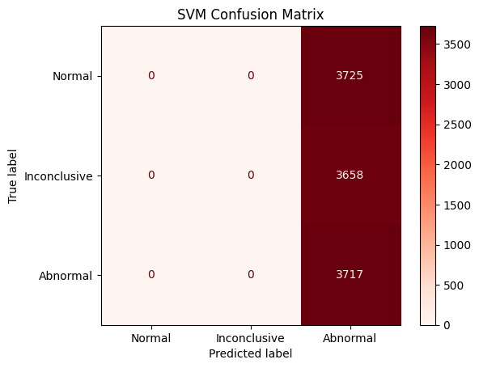

```python
svm_cm = confusion_matrix(y_valid, svm_pred)
            svm_disp = ConfusionMatrixDisplay(confusion_matrix = svm_cm,display_labels=target_names)
            svm_disp.plot(cmap = 'Reds')
            plt.title("SVM Confusion Matrix")
            plt.show()
```

##### **b. Decision Tree Classifier Model**

```python
# Import Libraries
            from sklearn.tree import DecisionTreeClassifier

            # Define the model
            dt_model = DecisionTreeClassifier(random_state=123)

            # Train the model
            dt_model.fit(X_train, y_train)

            # Make predictions
            dt_pred = dt_model.predict(X_valid)
```

```python
# Evaluate the model
            print(f'Accuracy Score: {round(accuracy_score(y_valid, dt_pred), 4)}')
            print(f'Precision Score: {round(precision_score(y_valid, dt_pred, average="weighted"), 4)}')
            print(f'Recall Score: {round(recall_score(y_valid, dt_pred, average="weighted"), 4)}')
            print(f'F1 Score: {round(f1_score(y_valid, dt_pred, average="weighted"), 4)}')
```

```
Accuracy Score: 0.4005
            Precision Score: 0.4006
            Recall Score: 0.4005
            F1 Score: 0.4005
```

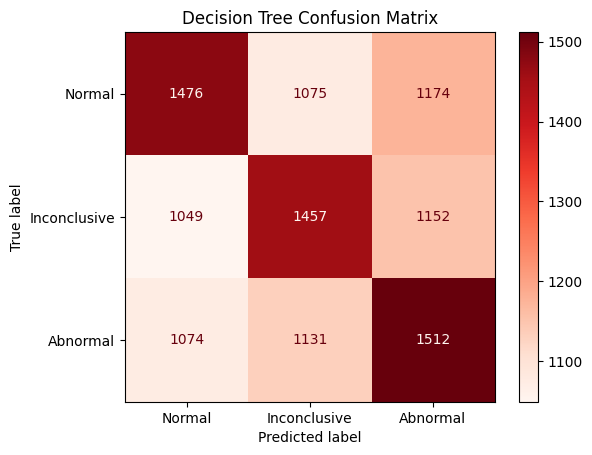

```python
dt_cm = confusion_matrix(y_valid, dt_pred)
            dt_disp = ConfusionMatrixDisplay(confusion_matrix = dt_cm,display_labels=target_names)
            dt_disp.plot(cmap = 'Reds')
            plt.title("Decision Tree Confusion Matrix")
            plt.show()
```

```python
dt_pred_y_train = dt_model.predict(X_train)
            print(f'Accuracy Score: {round(accuracy_score(y_train, dt_pred_y_train), 4)}')
            print(f'Precision Score: {round(precision_score(y_train,dt_pred_y_train, average="weighted"), 4)}')
            print(f'Recall Score: {round(recall_score(y_train,dt_pred_y_train, average="weighted"), 4)}')
            print(f'F1 Score: {round(f1_score(y_train,dt_pred_y_train, average="weighted"), 4)}')
```

```
Accuracy Score: 1.0
            Precision Score: 1.0
            Recall Score: 1.0
            F1 Score: 1.0
```

##### **c. XGBoost Classifier Model**

```python
# Import Libraries
            from xgboost import XGBClassifier

            # Define the model
            xgb_model = XGBClassifier(random_state=123)

            # Train the model
            xgb_model.fit(X_train, y_train)

            # Make predictions
            xgb_pred = xgb_model.predict(X_valid)
```

```python
# Evaluate the model
            print(f'Accuracy Score: {round(accuracy_score(y_valid, xgb_pred), 4)}')
            print(f'Precision Score: {round(precision_score(y_valid,xgb_pred, average="weighted"), 4)}')
            print(f'Recall Score: {round(recall_score(y_valid,xgb_pred, average="weighted"), 4)}')
            print(f'F1 Score: {round(f1_score(y_valid,xgb_pred, average="weighted"), 4)}')
```

```
Accuracy Score: 0.3605
            Precision Score: 0.3607
            Recall Score: 0.3605
            F1 Score: 0.3591
```

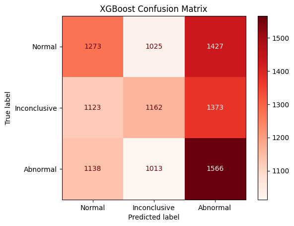

```python
xgb_cm = confusion_matrix(y_valid, xgb_pred)
            xgb_disp = ConfusionMatrixDisplay(confusion_matrix = xgb_cm,display_labels=target_names)
            xgb_disp.plot(cmap = 'Reds')
            plt.title("XGBoost Confusion Matrix")
            plt.show()
```

```python
xgb_pred_y_train = xgb_model.predict(X_train)
            print(f'Accuracy Score: {round(accuracy_score(y_train, xgb_pred_y_train), 4)}')
            print(f'Precision Score: {round(precision_score(y_train,xgb_pred_y_train, average="weighted"), 4)}')
            print(f'Recall Score: {round(recall_score(y_train,xgb_pred_y_train, average="weighted"), 4)}')
            print(f'F1 Score: {round(f1_score(y_train,xgb_pred_y_train, average="weighted"), 4)}')
```

```
Accuracy Score: 0.5398
            Precision Score: 0.5419
            Recall Score: 0.5398
            F1 Score: 0.5391
```

##### **d. Random Forest Classifier Model**

```python
# Import Libraries
            from sklearn.ensemble import RandomForestClassifier

            # Define the model
            rf_model = RandomForestClassifier(random_state=123)

            # Train the model
            rf_model.fit(X_train, y_train)

            # Make predictions
            rf_pred = rf_model.predict(X_valid)
```

```python
# Evaluate the model
            print(f'Accuracy Score: {round(accuracy_score(y_valid, rf_pred), 4)}')
            print(f'Precision Score: {round(precision_score(y_valid,rf_pred, average="weighted"), 4)}')
            print(f'Recall Score: {round(recall_score(y_valid,rf_pred, average="weighted"), 4)}')
            print(f'F1 Score: {round(f1_score(y_valid,rf_pred, average="weighted"), 4)}')
```

```
Accuracy Score: 0.4361
            Precision Score: 0.4361
            Recall Score: 0.4361
            F1 Score: 0.4361
```

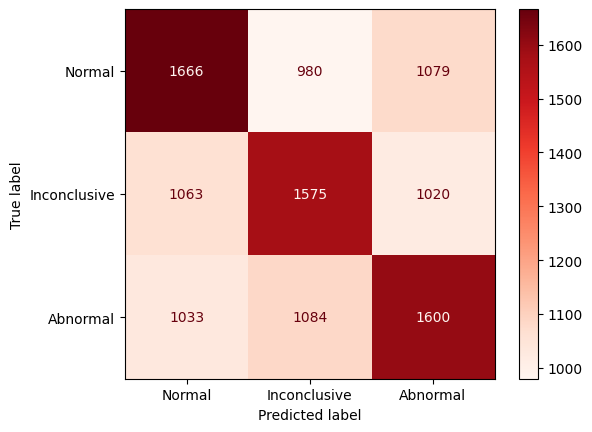

```python
rf_cm = confusion_matrix(y_valid, rf_pred)
            rf_disp = ConfusionMatrixDisplay(confusion_matrix = rf_cm,display_labels=target_names)
            rf_disp.plot(cmap = 'Reds')
            plt.show()
```

```python
rf_pred_y_train = rf_model.predict(X_train)
            print(f'Accuracy Score: {round(accuracy_score(y_train, rf_pred_y_train), 4)}')
            print(f'Precision Score: {round(precision_score(y_train,rf_pred_y_train, average="weighted"), 4)}')
            print(f'Recall Score: {round(recall_score(y_train,rf_pred_y_train, average="weighted"), 4)}')
            print(f'F1 Score: {round(f1_score(y_train,rf_pred_y_train, average="weighted"), 4)}')
```

```
Accuracy Score: 1.0
            Precision Score: 1.0
            Recall Score: 1.0
            F1 Score: 1.0
```

##### **e. Gradient Boost Machine (GBM) Classifier Model**

```python
# Import Libraries
            from sklearn.ensemble import GradientBoostingClassifier

            # Define the model
            gbm_model = GradientBoostingClassifier(random_state=123)

            # Train the model
            gbm_model.fit(X_train, y_train)

            # Make predictions
            gbm_pred = gbm_model.predict(X_valid)
```

```python
# Evaluate the model
            print(f'Accuracy Score: {round(accuracy_score(y_valid, gbm_pred), 4)}')
            print(f'Precision Score: {round(precision_score(y_valid,gbm_pred, average="weighted"), 4)}')
            print(f'Recall Score: {round(recall_score(y_valid,gbm_pred, average="weighted"), 4)}')
            print(f'F1 Score: {round(f1_score(y_valid,gbm_pred, average="weighted"), 4)}')
```

```
Accuracy Score: 0.3423
            Precision Score: 0.3427
            Recall Score: 0.3423
            F1 Score: 0.3112
```

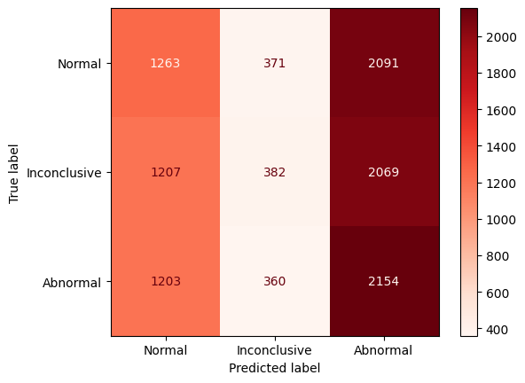

```python
gbm_cm = confusion_matrix(y_valid, gbm_pred)
            gbm_disp = ConfusionMatrixDisplay(confusion_matrix = gbm_cm,display_labels=target_names)
            gbm_disp.plot(cmap = 'Reds')
            plt.show()
```

```python
gbm_pred_y_train = gbm_model.predict(X_train)
            print(f'Accuracy Score: {round(accuracy_score(y_train, gbm_pred_y_train), 4)}')
            print(f'Precision Score: {round(precision_score(y_train,gbm_pred_y_train, average="weighted"), 4)}')
            print(f'Recall Score: {round(recall_score(y_train,gbm_pred_y_train, average="weighted"), 4)}')
            print(f'F1 Score: {round(f1_score(y_train,gbm_pred_y_train, average="weighted"), 4)}')
```

```
Accuracy Score: 0.3916
            Precision Score: 0.4164
            Recall Score: 0.3916
            F1 Score: 0.3638
```

**Using Label Encoding with scaling Instead**

```python
# Splitting data

            from sklearn.model_selection import train_test_split

            new_health_data['test_results'] = new_health_data['test_results'].map({'Normal':0, 'Inconclusive':1, 'Abnormal':2})

            X_data = new_health_data.drop(columns=['test_results'])
            y_data = new_health_data['test_results']
            X_train, X_valid, y_train, y_valid = train_test_split(X_data, y_data, test_size=0.2, random_state=123)
```

```python
# Identifying categorical and numeric columns
            numeric_columns = X_data.select_dtypes(include=np.number).columns.tolist()
            categorical_columns = X_data.select_dtypes(include=['category', 'object']).columns.tolist()

            from sklearn.preprocessing import LabelEncoder

            # Scalling Numeric data

            # Define the scaler
            scaler = MinMaxScaler().fit(X_data[numeric_columns])
            X_train[numeric_columns] = scaler.transform(X_train[numeric_columns])
            X_valid[numeric_columns] = scaler.transform(X_valid[numeric_columns])

            # Encode Categorical Columns
            le = LabelEncoder()
            X_train['gender_encoded'] = le.fit_transform(X_train['gender'])
            X_valid['gender_encoded'] = le.fit_transform(X_valid['gender'])
            X_train['rooms_encoded'] = le.fit_transform(X_train['new_room_number'])
            X_valid['rooms_encoded'] = le.fit_transform(X_valid['new_room_number'])
            X_train = X_train.drop(columns = categorical_columns)
            X_valid = X_valid.drop(columns = categorical_columns)
```

##### **a. Support Vector Machine (SVM) Classifier Model**

```python
# Import Libraries
            from sklearn.svm import SVC

            # Define the model
            svm_model = SVC(random_state=123, C=1, kernel='rbf', gamma='auto')

            # Train the model
            svm_model.fit(X_train, y_train)
```

```
SVC(C=1, gamma='auto', random_state=123)
```

```python
# Make predictions
            svm_pred = svm_model.predict(X_valid)
```

```python
# Evaluate the model
            print(f'Accuracy Score: {round(accuracy_score(y_valid, svm_pred), 4)}')
            print(f'Precision Score: {round(precision_score(y_valid,svm_pred, average="weighted"), 4)}')
            print(f'Recall Score: {round(recall_score(y_valid,svm_pred, average="weighted"), 4)}')
            print(f'F1 Score: {round(f1_score(y_valid,svm_pred, average="weighted"), 4)}')
```

```
Accuracy Score: 0.352
            Precision Score: 0.3517
            Recall Score: 0.352
            F1 Score: 0.3513
```

```python
# Evaluate the model
            svm_pred_y_train = svm_model.predict(X_train)
```

```python
print(f'Accuracy Score: {round(accuracy_score(y_train, svm_pred_y_train), 4)}')
            print(f'Precision Score: {round(precision_score(y_train,svm_pred_y_train, average="weighted"), 4)}')
            print(f'Recall Score: {round(recall_score(y_train,svm_pred_y_train, average="weighted"), 4)}')
            print(f'F1 Score: {round(f1_score(y_train,svm_pred_y_train, average="weighted"), 4)}')
```

```
Accuracy Score: 0.4052
            Precision Score: 0.4056
            Recall Score: 0.4052
            F1 Score: 0.4046
```

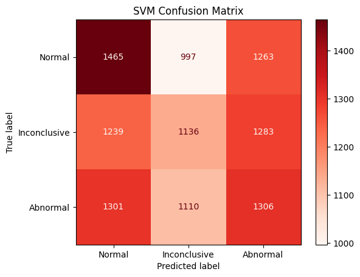

```python
svm_cm = confusion_matrix(y_valid, svm_pred)
            svm_disp = ConfusionMatrixDisplay(confusion_matrix = svm_cm,display_labels=target_names)
            svm_disp.plot(cmap = 'Reds')
            plt.title("SVM Confusion Matrix")
            plt.show()
```

##### **b. Decision Tree Classifier Model**

```python
# Import Libraries
            from sklearn.tree import DecisionTreeClassifier

            # Define the model
            dt_model = DecisionTreeClassifier(random_state=123)

            # Train the model
            dt_model.fit(X_train, y_train)

            # Make predictions
            dt_pred = dt_model.predict(X_valid)
```

```python
# Evaluate the model
            print(f'Accuracy Score: {round(accuracy_score(y_valid, dt_pred), 4)}')
            print(f'Precision Score: {round(precision_score(y_valid, dt_pred, average="weighted"), 4)}')
            print(f'Recall Score: {round(recall_score(y_valid, dt_pred, average="weighted"), 4)}')
            print(f'F1 Score: {round(f1_score(y_valid, dt_pred, average="weighted"), 4)}')
```

```
Accuracy Score: 0.4012
            Precision Score: 0.4012
            Recall Score: 0.4012
            F1 Score: 0.4012
```

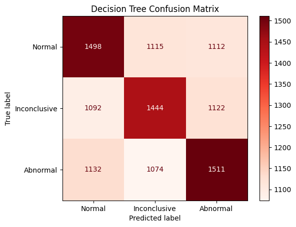

```python
dt_cm = confusion_matrix(y_valid, dt_pred)
            dt_disp = ConfusionMatrixDisplay(confusion_matrix = dt_cm,display_labels=target_names)
            dt_disp.plot(cmap = 'Reds')
            plt.title("Decision Tree Confusion Matrix")
            plt.show()
```

```python
dt_pred_y_train = dt_model.predict(X_train)
            print(f'Accuracy Score: {round(accuracy_score(y_train, dt_pred_y_train), 4)}')
            print(f'Precision Score: {round(precision_score(y_train,dt_pred_y_train, average="weighted"), 4)}')
            print(f'Recall Score: {round(recall_score(y_train,dt_pred_y_train, average="weighted"), 4)}')
            print(f'F1 Score: {round(f1_score(y_train,dt_pred_y_train, average="weighted"), 4)}')
```

```
Accuracy Score: 1.0
            Precision Score: 1.0
            Recall Score: 1.0
            F1 Score: 1.0
```

##### **c. XGBoost Classifier Model**

```python
# Import Libraries
            from xgboost import XGBClassifier

            # Define the model
            xgb_model = XGBClassifier(random_state=123)

            # Train the model
            xgb_model.fit(X_train, y_train)

            # Make predictions
            xgb_pred = xgb_model.predict(X_valid)
```

```python
# Evaluate the model
            print(f'Accuracy Score: {round(accuracy_score(y_valid, xgb_pred), 4)}')
            print(f'Precision Score: {round(precision_score(y_valid,xgb_pred, average="weighted"), 4)}')
            print(f'Recall Score: {round(recall_score(y_valid,xgb_pred, average="weighted"), 4)}')
            print(f'F1 Score: {round(f1_score(y_valid,xgb_pred, average="weighted"), 4)}')
```

```
Accuracy Score: 0.3601
            Precision Score: 0.3601
            Recall Score: 0.3601
            F1 Score: 0.36
```

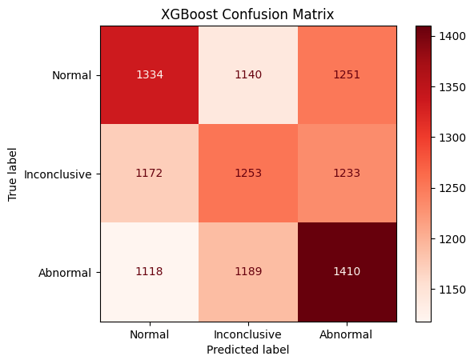

```python
xgb_cm = confusion_matrix(y_valid, xgb_pred)
            xgb_disp = ConfusionMatrixDisplay(confusion_matrix = xgb_cm,display_labels=target_names)
            xgb_disp.plot(cmap = 'Reds')
            plt.title("XGBoost Confusion Matrix")
            plt.show()
```

```python
xgb_pred_y_train = xgb_model.predict(X_train)
            print(f'Accuracy Score: {round(accuracy_score(y_train, xgb_pred_y_train), 4)}')
            print(f'Precision Score: {round(precision_score(y_train,xgb_pred_y_train, average="weighted"), 4)}')
            print(f'Recall Score: {round(recall_score(y_train,xgb_pred_y_train, average="weighted"), 4)}')
            print(f'F1 Score: {round(f1_score(y_train,xgb_pred_y_train, average="weighted"), 4)}')
```

```
Accuracy Score: 0.622
            Precision Score: 0.6222
            Recall Score: 0.622
            F1 Score: 0.622
```

##### **d. Random Forest Classifier Model**

```python
# Import Libraries
            from sklearn.ensemble import RandomForestClassifier

            # Define the model
            rf_model = RandomForestClassifier(random_state=123)

            # Train the model
            rf_model.fit(X_train, y_train)

            # Make predictions
            rf_pred = rf_model.predict(X_valid)
```

```python
# Evaluate the model
            print(f'Accuracy Score: {round(accuracy_score(y_valid, rf_pred), 4)}')
            print(f'Precision Score: {round(precision_score(y_valid,rf_pred, average="weighted"), 4)}')
            print(f'Recall Score: {round(recall_score(y_valid,rf_pred, average="weighted"), 4)}')
            print(f'F1 Score: {round(f1_score(y_valid,rf_pred, average="weighted"), 4)}')
```

```
Accuracy Score: 0.4305
            Precision Score: 0.4304
            Recall Score: 0.4305
            F1 Score: 0.4304
```

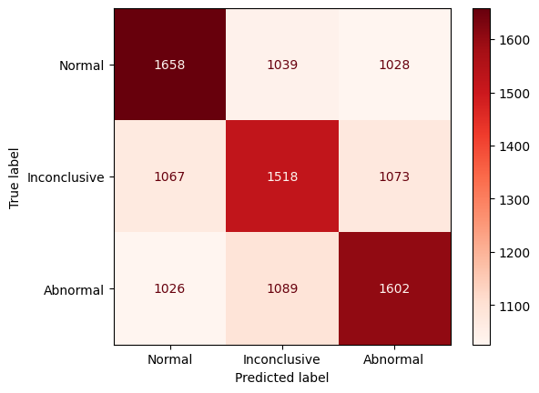

```python
rf_cm = confusion_matrix(y_valid, rf_pred)
            rf_disp = ConfusionMatrixDisplay(confusion_matrix = rf_cm,display_labels=target_names)
            rf_disp.plot(cmap = 'Reds')
            plt.show()
```

```python
rf_pred_y_train = rf_model.predict(X_train)
            print(f'Accuracy Score: {round(accuracy_score(y_train, rf_pred_y_train), 4)}')
            print(f'Precision Score: {round(precision_score(y_train,rf_pred_y_train, average="weighted"), 4)}')
            print(f'Recall Score: {round(recall_score(y_train,rf_pred_y_train, average="weighted"), 4)}')
            print(f'F1 Score: {round(f1_score(y_train,rf_pred_y_train, average="weighted"), 4)}')
```

```
Accuracy Score: 1.0
            Precision Score: 1.0
            Recall Score: 1.0
            F1 Score: 1.0
```

##### **e. Gradient Boost Machine (GBM) Classifier Model**

```python
# Import Libraries
            from sklearn.ensemble import GradientBoostingClassifier

            # Define the model
            gbm_model = GradientBoostingClassifier(random_state=123)

            # Train the model
            gbm_model.fit(X_train, y_train)

            # Make predictions
            gbm_pred = gbm_model.predict(X_valid)
```

```python
# Evaluate the model
            print(f'Accuracy Score: {round(accuracy_score(y_valid, gbm_pred), 4)}')
            print(f'Precision Score: {round(precision_score(y_valid,gbm_pred, average="weighted"), 4)}')
            print(f'Recall Score: {round(recall_score(y_valid,gbm_pred, average="weighted"), 4)}')
            print(f'F1 Score: {round(f1_score(y_valid,gbm_pred, average="weighted"), 4)}')
```

```
Accuracy Score: 0.3444
            Precision Score: 0.3446
            Recall Score: 0.3444
            F1 Score: 0.3403
```

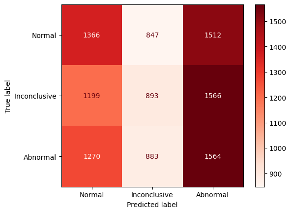

```python
gbm_cm = confusion_matrix(y_valid, gbm_pred)
            gbm_disp = ConfusionMatrixDisplay(confusion_matrix = gbm_cm,display_labels=target_names)
            gbm_disp.plot(cmap = 'Reds')
            plt.show()
```

```python
gbm_pred_y_train = gbm_model.predict(X_train)
            print(f'Accuracy Score: {round(accuracy_score(y_train, gbm_pred_y_train), 4)}')
            print(f'Precision Score: {round(precision_score(y_train,gbm_pred_y_train, average="weighted"), 4)}')
            print(f'Recall Score: {round(recall_score(y_train,gbm_pred_y_train, average="weighted"), 4)}')
            print(f'F1 Score: {round(f1_score(y_train,gbm_pred_y_train, average="weighted"), 4)}')
```

```
Accuracy Score: 0.4032
            Precision Score: 0.4053
            Recall Score: 0.4032
            F1 Score: 0.3994
```